# Jacobian

Ottar N. Bjornstad and Aaron King

07/14/2023

Version 0.5-9 Jul 14, 2023 https://github.com/objornstad

This Rmarkdown of a general purpose jacobian calculator was written by Ottar N. Bjørnstad and Aaron King is released with a CC-BY-NC lisence for anyone to improve and re-share (acknowledging origin). Please email me a copy of update (onb1 at psu dot edu). The app was developed as part of the epimdr-project (https://cran.r-project.org/package=epimdr; Bjørnstad 2018).

**MOTIVATION** For stability analysis, ressonant periodicity, transfer-functions, etc, etc we usually need the Jacobian matrix evaluated with parameters and at some point in the phase plane.

A general purpose function is (with Aaron King’s one-upmanship at the bottom):

```r
jacobian=function(states, elist, params, pts){
paras = as.list(c(pts, params))

k=0
jl=list(NULL)
for(i in 1:length(states)){
assign(paste("jj", i, sep = "."), lapply(lapply(elist, deriv, states[i]), eval, paras))
for(j in 1:length(states)){
k=k+1
jl[[k]]=attr(eval(as.name(paste("jj", i, sep=".")))[[j]], "gradient")[1,]
}
}

J=matrix(as.numeric(as.matrix(jl)[,1]), ncol=length(states))
return(J)
}
```

**states** is a vector naming all *state variables*,

**elist** is a list that contains equations (**quotes**) for all states,

**params** is a *labeled vector* of parameters,

**pts** is a a *labeled vector* of the point in the phase plane to evaluate the Jacobian (often the endemic or disease-free equilibrium if working in mathematical epidemiology; or some other equilibrium if working in ecology).

EXAMPLE 1 SIR (Bjornstad 2018: page 21)

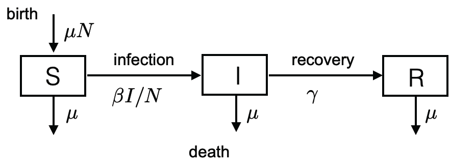

Lets consider the SIR model. The basic equations for the flow of hosts between **S**usceptible, **I**nfectious and **R**ecovered compartments are:

$\begin{aligned} \frac{dS}{dt} =& \underbrace{\mu N}_{\mbox{birth}} - \underbrace{\beta I \frac{S}{N}}_{\mbox{infection}} - \underbrace{\mu S}_{\mbox{death}} \label{eq:sirs}\\ \frac{dI}{dt} =& \underbrace{\beta I \frac{S}{N}}_{\mbox{infection}} - \underbrace{\gamma I}_{\mbox{recovery}} - \underbrace{\mu I}_{\mbox{death}} \label{eq:siri}\\ \frac{dR}{dt} =& \underbrace{\gamma I}_{\mbox{recovery}} - \underbrace{\mu R}_{\mbox{death}} \label{eq:sirr} \end{aligned}$

Infected individuals infectious for an average time of $1/(\gamma+\mu)$ time units. The transmission rate is $\beta$. Because **R** is absobing and does not affect dynamics when we work on compartementalfractions ($N = 1$) we omit this equation.

Step 1: classes are S and I

```r
states=c("S", "I")
```

Step 2: Equations are:

```r
elist=c(dSdt = quote(mu * (N  - S)  - beta * S * I / N),
dIdt = quote(beta * S * I / N - (mu + gamma) * I))
```

Step 3: Some arbitrary parameters are:

```r
parms  = c(mu = 1/(50*52), N = 1, beta =  2,
      gamma = 1/2)
```

```r
eeq=with(as.list(parms), c(I=(gamma+mu)/beta, S=mu*(beta/(gamma+mu)-1)/beta))
deq = list(S = 1, I = 0, R = 0)
```

Invoke Jacobian calculator:

```r
JJ=jacobian(states=states, elist=elist, params=parms, pts=eeq)
JJ
```

```
##            [,1]         [,2]
## [1,] -0.5007692 -0.001152664
## [2,]  0.5003846 -0.499231952
```

Eigen values are:

```r
eigen(JJ)$value
```

```
## [1] -0.5000006+0.0240038i -0.5000006-0.0240038i
```

A pair of comnplex conjugates. So the endemic equilibrium is a stable focus. The ressonant periodicity is:

```r
2*pi/Im(eigen(JJ)$value[1])
```

```
## [1] 261.7575
```

We next look at the disease-free equilibrium:

```r
deq = list(S = 1, I = 0, R = 0)
JJ=jacobian(states=states, elist=elist, params=parms, pts=deq)
#Eigen values are:
eigen(JJ)$value
```

```
## [1]  1.4996153846 -0.0003846154
```

The dominant EV is real

EXAMPLE 2: SEIR

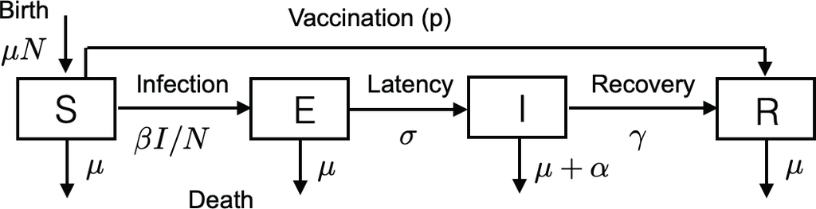

the SEIR model of the flow of hosts between **S**usceptible, **E**xposed (but not yet infectious), **I**nfectious and **R**ecovered compartments in a randomly mixing population:

where, susceptibles are either vaccinated at birth (fraction $p$), or infected at a rate $\beta I / N$. Infected individuals will remain in the latent class for an average period of $1/(\sigma +\mu)$ and subsequently (if they escape natural mortality at a rate $\mu$) enter the infectious class for an average time of $1/(\gamma+\mu+\alpha)$; $\alpha$ is the *rate* of disease induced mortality (*not* case fatality rate). By the rules of competing rates , the case fatality rate is $\alpha/(\gamma+\mu+\alpha)$ because during the time an individual is expected to remain in the infectious class the disease is killing them at a rate $\alpha$. By a similar logic, the probability of recovering with immunity (for life in the case of the SEIR model) is $\gamma/(\gamma+\mu+\alpha)$. Putting all these pieces together, and assuming no vaccination, the expected number of secondary cases in a completely susceptible population is thus: probability of making it through latent stage without dying * expected infectious period * transmission rate while infectious. Thus, $R_0 = \frac{\sigma}{\sigma +\mu} \frac{1}{\gamma+\mu+\alpha} \frac{\beta N}{N} = \frac{\sigma}{\sigma +\mu} \frac{\beta}{\gamma+\mu+\alpha}$.

```r
states2=c("S", "E", "I", "R")
```

```r
elist2=c(dS = quote(mu * (N  - S)  - beta * S * I / N),
  dE = quote(beta * S * I / N - (mu + sigma) * E),
  dI = quote(sigma * E - (mu + gamma+alpha) * I),
 dR = quote(gamma * I - mu * R))
```

```r
paras2  = c(mu = 1/50, N = 1, beta =  1000,
     sigma = 365/8, gamma = 365/5, alpha=0)
```

```r
deq2=list(S = 1, E = 0, I = 0, R = 0)
```

```r
JJ=jacobian(states=states2, elist=elist2, params=paras2, pts=deq2)
eigen(JJ)$value
```

```
## [1] -273.3707  154.7057   -0.0200   -0.0200
```

EXAMPLE 3: The Rosenzweig-MacArthur predator-prey model.

The basic equations for the consumer-resource interaction between prey (N) and predators (P) are:

$\begin{aligned} \frac{dN}{dt} &= \underbrace{r N (\frac{K-N}{K})}_{\mbox{N growth}} - \underbrace{\frac{a N P}{c + N}}_{\mbox{predation}}\\ \frac{dP}{dt} &= \underbrace{\frac{b N P}{c + N}}_{\mbox{P growth}} - \underbrace{g P}_{\mbox{P death}} \end{aligned}$

Prey ($N$) are assumed to grow acording to the logistic model with a maximum growth rate, $r$ and carrying-capacity, $K$. P redators ($P$)are feeding according to a Type-II functional respose with a maximum search efficiency, $a$ and half-saturation constant $c$. Predators have a conversion efficiency of $b/a$ and a life-expectancy of $1/g$.

The isoclines (sometimes called the nullclines) of this system are given by the solution to the equations $\frac{dN}{dt} = 0$ and $\frac{dP}{dt} = 0$ and partitions the phase plane into regions were $N$ and $P$ are increasing and decreasing. The $N$-isocline is $P = (r-rN/K)(c+N)/a$ and the P-isocline is $N = gc/(b-g)$. The equilibrium is $\{N^* = gc/(b-g), P^* = (r-rN^*/K)(c+N^*)/a\}$

```r
states3=c("N", "P")
```

```r
elist3=c(dN = quote(r *N *((K-N)/K) - a *N *P/(c + N)),
     dP =quote(b*N*P/(c + N) - g*P))
```

```r
paras3  = c(r=0.1, K=90, a=0.2, c=20, b=0.1, g=0.05)
```

```r
eq3=with(as.list(paras3), c(N=g*c/(b-g), P=(r-r*g*c/(b-g)/K)*(c+g*c/(b-g))/a))
```

```r
JJ=jacobian(states=states3, elist=elist3, params=paras3, pts=eq3)
eigen(JJ)$value
```

```
## [1] 0.00833333+0.04330127i 0.00833333-0.04330127i
```

Equilibrium is an unstable focus with damping period of:

```r
2*pi/Im(eigen(JJ)$value[1])
```

```
## [1] 145.1039
```

AARONS FIRST TINKER:

MORE EXAMPLES with Aarons one-upmanship: “I can see how useful it will be. This kind of programming in R seems unavoidably tortuous, but it is amazing how far one can push things in the general lisp-like structure of R.

I can’t read code without tinkering with it, so I played around a bit with your Jacobian calculator. I thought it might be interesting to have one that returns a function for the Jacobian that can be evaluated at multiple points.  
Then I thought I’d see how far I could go in terms of making the calling syntax simpler. What do you think of the attached?

This will only run on the latest R (4.1) because of the native pipes it uses in places. It would be trivial to remove those, but as you know I am addicted to pipes. (I got absurdly excited about 4.1).”

```r
stopifnot(getRversion()>="4.1")

Jacobian <- function (.vars, ...) {
  vf <- substitute(list(...))[-1L]
  vars <- sapply(substitute(.vars),deparse)
  if (length(vars)>1) vars <- vars[-1L]
  sapply(
    vars,
    \(var) sapply(vf,D,name=var)
  ) -> jac
  dd <- c(length(vf),length(vars))
  dim(jac) <- NULL
  dn <- list(
    ifelse(
      nzchar(names(vf)),
      names(vf),
      sapply(vf,deparse)
    ),
    vars
  )
  fun <- function (...) {
    e <- c(as.list(sys.frame(sys.nframe())),...)
    J <- vapply(jac,eval,numeric(1L),envir=e)
    dim(J) <- dd
    dimnames(J) <- dn
    J
  }
  formals(fun) <- eval(
    parse(text=paste0("alist(",paste0(c(vars,"..."),"=",collapse=","),")"))
  )
  fun
}
```

Alternatively, we may wish to have a function which evaluates the Jacobian at a specified point. The following function returns such a function. It makes use of non-standard evaluation and the function-associated environment feature of **R**.

```r
Jacobian <- function (..., variables) {
  vf <- substitute(list(...))[-1L]
  if (missing(variables)) {
    vars <- all.vars(vf)
  } else {
    vars <- sapply(substitute(variables),deparse)
    if (length(vars)>1) vars <- vars[-1L]
  }
  sapply(
    vars,
    function (var) sapply(vf,D,name=var)
  ) -> jac
  dd <- c(length(vf),length(vars))
  dim(jac) <- NULL
  dn <- list(
    ifelse(
      nzchar(names(vf)),
      names(vf),
      sapply(vf,deparse)
    ),
    vars
  )
  fun <- function (...) {
    e <- c(as.list(sys.frame(sys.nframe())),...)
    J <- vapply(jac,eval,numeric(1L),envir=e)
    dim(J) <- dd
    dimnames(J) <- dn
    J
  }
  formals(fun) <- eval(
    parse(text=paste0("alist(",paste0(c(vars,"..."),"=",collapse=","),")"))
  )
  fun
}
```

```r
Jacobian(sin(x),cos(x),atan(y/x),tan(x+y)) -> f
f
```

```
## function (x, y, ...)
## {
##     e <- c(as.list(sys.frame(sys.nframe())), ...)
##     J <- vapply(jac, eval, numeric(1L), envir = e)
##     dim(J) <- dd
##     dimnames(J) <- dn
##     J
## }
## <environment: 0x7ff876f72de8>
```

```r
try(f())
```

```
## Error in FUN(X[[i]], ...) : argument "x" is missing, with no default
```

```r
f(3,2)
```

```
##               x          y
## [1,] -0.9899925  0.0000000
## [2,] -0.1411200  0.0000000
## [3,] -0.1538462  0.2307692
## [4,] 12.4278817 12.4278817
```

```r
f(y=2,x=3)
```

```
##               x          y
## [1,] -0.9899925  0.0000000
## [2,] -0.1411200  0.0000000
## [3,] -0.1538462  0.2307692
## [4,] 12.4278817 12.4278817
```

```r
Jacobian(x,sin(x),cos(x),atan(y/x),tan(x+y),factorial(x)) -> f
f
```

```
## function (x, y, ...)
## {
##     e <- c(as.list(sys.frame(sys.nframe())), ...)
##     J <- vapply(jac, eval, numeric(1L), envir = e)
##     dim(J) <- dd
##     dimnames(J) <- dn
##     J
## }
## <environment: 0x7ff8808a9200>
```

```r
try(f(x=3))
```

```
## Error in FUN(X[[i]], ...) : argument "y" is missing, with no default
```

```r
f(x=3,y=2)
```

```
##               x          y
## [1,]  1.0000000  0.0000000
## [2,] -0.9899925  0.0000000
## [3,] -0.1411200  0.0000000
## [4,] -0.1538462  0.2307692
## [5,] 12.4278817 12.4278817
## [6,]  7.5367060  0.0000000
```

```r
Jacobian(
  variables=c(x,y),
  A=sin(x),
  B=cos(x),
  atan(y/x),
  D=tan(x+y),
  `x!`=factorial(x)
) -> f
f(y=3,x=2)
```

```
##                    x          y
## A         -0.4161468  0.0000000
## B         -0.9092974  0.0000000
## atan(y/x) -0.2307692  0.1538462
## D         12.4278817 12.4278817
## x!         1.8455687  0.0000000
```

### SIR example:

```r
Jacobian(
  dSdt=mu*(S+I+R)-beta*S*I/(S+I+R)-mu*S,
  dIdt=beta*S*I/(S+I+R)-gamma*I-(mu+alpha)*I,
  dRdt=gamma*I-mu*R,
  variables=c(S,I,R)
) -> f

f
```

```
## function (S, I, R, ...)
## {
##     e <- c(as.list(sys.frame(sys.nframe())), ...)
##     J <- vapply(jac, eval, numeric(1L), envir = e)
##     dim(J) <- dd
##     dimnames(J) <- dn
##     J
## }
## <environment: 0x7ff876b5a8d8>
```

```r
try(f(S=0.99,I=0.01,R=0))
```

```
## Error in FUN(X[[i]], ...) : object 'mu' not found
```

```r
f(S=0.99,I=0.01,R=0,mu=0.02,beta=400,gamma=26,alpha=1)
```

```
##          S       I     R
## dSdt -0.04 -392.02  3.98
## dIdt  0.04  365.02 -3.96
## dRdt  0.00   26.00 -0.02
```

```r
with(
  list(gamma=26,beta=400,alpha=1,mu=0.02),
  f(
    S=(gamma+mu)/beta,
    I=(1-(gamma+mu)/beta)*mu/(gamma+mu),
    R=(1-(gamma+mu)/beta)*gamma/(gamma+mu),
    mu=mu,beta=beta,gamma=gamma,alpha=alpha
  )
)|>
  eigen() |>
  getElement("values")
```

```
## [1] -0.6533818978+2.709344i -0.6533818978-2.709344i -0.0006920076+0.000000i
```

By default, we take derivatives with respect to all variables in the vectorfield expression.

```r
Jacobian(
  dSdt=mu*(S+I+R)-beta*S*I/(S+I+R)-mu*S,
  dIdt=beta*S*I/(S+I+R)-gamma*I-(mu+alpha)*I,
  dRdt=gamma*I-mu*R
) -> f
f
```

[output not shown]

```r
f(S=0.99,I=0.01,R=0,mu=0.02,beta=400,gamma=26,alpha=1)
```

[output not shown]

### Rosenzweig-MacArthur example:

```r
Jacobian(
  dN = r*N*((K-N)/K) - a*N*P/(c+N),
  dP = b*N*P/(c+N) - g*P,
  variables=c(N,P)
) -> f

with(
  list(r=0.1,K=90,a=0.2,c=20,b=0.1,g=0.05),
  f(
    r=r,K=K,a=a,c=c,b=b,g=g,
    N=g*c/(b-g),
    P=(r-r*g*c/(b-g)/K)*(c+g*c/(b-g))/a)
) |>
  eigen() |>
  getElement("values")
```

```
## [1] 0.00833333+0.04330127i 0.00833333-0.04330127i
```